# Projecting Fantasy Football Points Using Current Game Status

#### December 2022

## 1. Introduction

### 1.1 What is Fantasy Football?

Fantasy football is an online game for people who watch the NFL in which competitors form leagues (typically of size 8-16) with friends and draft NFL players to compete for them. Each NFL play awards points to fantasy players based on their performance on a given play. There are a few different popular scoring methods, but in this project, I will focus on scoring from a typical "PPR" league, which is as follows:

- 1 point to the receiver for a reception
- 0.1 points per receiving yard
- 0.1 points per rushing yard
- 6 points for a rushing or receiving touchdown
- 0.04 points per passing yard
- 4 points for a passing touchdown

There are a few other ways to gain or lose points (such as fumbling) but for the purposes of this project, I'll stick to the list above. Also, we are only going to be dealing with receiving, rushing and passing, so defenses and kickers will be excluded.

### 1.2 Projections

To help players make roster decisions, fantasy websites provide a projected point value for each player. As the games are in progress, players can view an updated projection for each player as well as for their whole team in order to see how they are stacking up to their competition. This in-game projection is calculated by dividing the projection by the portion of time left in the game. However, this system is clearly flawed and could be improved upon. Creating a more accurate live projection is the intent of the project.

## 2. Acquiring Data

### 2.1 nfl-data-py

For the majority of the data in this project, I will be using a Python package called nfl-data-py. Information about this dataset can be found at https://pypi.org/project/nfl-data-py/. \ This package is a way to access data from multiple previously collected datasets as outlined on the page above. It will make it very easy for us to access and manipulate most of our data. To begin, I will be importing their table for general team descriptions for visualizations, the table for rosters, and as the play-by-play data from 2012-2021 which I will use for the majority of our analysis.

```python
!pip install nfl_data_py
```

[output not shown]

```python
import nfl_data_py as nfl
import numpy as np
import pandas as pd
import matplotlib.pyplot as plt
import seaborn as sns
import requests
```

```python
team_desc = nfl.import_team_desc()
team_desc.head()
```

|  | team_abbr | team_name | team_id | team_nick | team_conf | team_division | team_color | team_color2 | team_color3 | team_color4 | team_logo_wikipedia | team_logo_espn | team_wordmark | team_conference_logo | team_league_logo | team_logo_squared |
| --- | --- | --- | --- | --- | --- | --- | --- | --- | --- | --- | --- | --- | --- | --- | --- | --- |
| 0 | ARI | Arizona Cardinals | 3800 | Cardinals | NFC | NFC West | #97233F | #000000 | #ffb612 | #a5acaf | https://upload.wikimedia.org/wikipedia/en/thum... | https://a.espncdn.com/i/teamlogos/nfl/500/ari.png | https://github.com/nflverse/nflverse-pbp/raw/m... | https://github.com/nflverse/nflverse-pbp/raw/m... | https://raw.githubusercontent.com/nflverse/nfl... | https://github.com/nflverse/nflverse-pbp/raw/m... |
| 1 | ATL | Atlanta Falcons | 200 | Falcons | NFC | NFC South | #A71930 | #000000 | #a5acaf | #a30d2d | https://upload.wikimedia.org/wikipedia/en/thum... | https://a.espncdn.com/i/teamlogos/nfl/500/atl.png | https://github.com/nflverse/nflverse-pbp/raw/m... | https://github.com/nflverse/nflverse-pbp/raw/m... | https://raw.githubusercontent.com/nflverse/nfl... | https://github.com/nflverse/nflverse-pbp/raw/m... |
| 2 | BAL | Baltimore Ravens | 325 | Ravens | AFC | AFC North | #241773 | #9E7C0C | #9e7c0c | #c60c30 | https://upload.wikimedia.org/wikipedia/en/thum... | https://a.espncdn.com/i/teamlogos/nfl/500/bal.png | https://github.com/nflverse/nflverse-pbp/raw/m... | https://github.com/nflverse/nflverse-pbp/raw/m... | https://raw.githubusercontent.com/nflverse/nfl... | https://github.com/nflverse/nflverse-pbp/raw/m... |
| 3 | BUF | Buffalo Bills | 610 | Bills | AFC | AFC East | #00338D | #C60C30 | #0c2e82 | #d50a0a | https://upload.wikimedia.org/wikipedia/en/thum... | https://a.espncdn.com/i/teamlogos/nfl/500/buf.png | https://github.com/nflverse/nflverse-pbp/raw/m... | https://github.com/nflverse/nflverse-pbp/raw/m... | https://raw.githubusercontent.com/nflverse/nfl... | https://github.com/nflverse/nflverse-pbp/raw/m... |
| 4 | CAR | Carolina Panthers | 750 | Panthers | NFC | NFC South | #0085CA | #000000 | #bfc0bf | #0085ca | https://upload.wikimedia.org/wikipedia/en/thum... | https://a.espncdn.com/i/teamlogos/nfl/500-dark... | https://github.com/nflverse/nflverse-pbp/raw/m... | https://github.com/nflverse/nflverse-pbp/raw/m... | https://raw.githubusercontent.com/nflverse/nfl... | https://github.com/nflverse/nflverse-pbp/raw/m... |

```python
rosters = nfl.import_rosters(range(2012, 2022), ['season', 'team', 'position',
                                                 'player_name', 'player_id'])
rosters.head()
```

|  | season | team | position | player_name | player_id |
| --- | --- | --- | --- | --- | --- |
| 0 | 2012 | ARZ | C | Lyle Sendlein | 00-0025682 |
| 1 | 2012 | ARZ | CB | Michael Adams | 00-0025668 |
| 2 | 2012 | ARZ | CB | Jamell Fleming | 00-0029639 |
| 3 | 2012 | ARZ | CB | William Gay | 00-0025557 |
| 4 | 2012 | ARZ | CB | Patrick Peterson | 00-0027943 |

```python
pbp = nfl.import_pbp_data(range(2012, 2022),
                          ['season_type', 'week', 'posteam', 'defteam',
                           'yardline_100', 'quarter_seconds_remaining',
                           'half_seconds_remaining', 'game_seconds_remaining',
                           'qtr', 'down', 'ydstogo', 'desc', 'play_type',
                           'air_yards', 'run_gap', 'td_player_name',
                           'td_player_id', 'posteam_score', 'defteam_score',
                           'incomplete_pass', 'interception', 'pass_touchdown',
                           'rush_touchdown', 'two_point_attempt',
                           'passer_player_id', 'passer_player_name',
                           'passing_yards', 'receiver_player_id',
                           'receiver_player_name', 'receiving_yards',
                           'rusher_player_id', 'rusher_player_name',
                           'rushing_yards', 'spread_line', 'total_line'])
print(f'{len(pbp)} rows')
pbp.head()['rusher_player_id']
```

```
2012 done.
2013 done.
2014 done.
2015 done.
2016 done.
2017 done.
2018 done.
2019 done.
2020 done.
2021 done.
Downcasting floats.
```

```
486293 rows
```

```
0          None
1          None
2    00-0022821
3    00-0022821
4          None
Name: rusher_player_id, dtype: object
```

As you can see, even with our restrictions the table still has nearly 500000 rows (one row for each play) so we're still going to have to consider the size when deciding on our calculations.

### 2.2 FantasyPros Projections

FantasyPros is a popular site that is well regarded among serious fantasy players. They publish weekly projections for each player that we will use to test our models. However, only the projections from the current season are available to scrape, so we will only have 13 weeks worth of data to test on. On the other hand, this provides an easy way for us to divide our training data and test data since we will only test on the 2022 season. \ We will use the requests package and pandas' readhtml function in order to parse this data.

```python
url = 'http://www.fantasypros.com/nfl/projections/qb'
qb_proj = pd.DataFrame()
for week in range(1, 14): # Iterate over weeks 1-13
  params = {'week': week, 'scoring': 'PPR'}
  resp = requests.get(url, params=params)
  df = pd.io.html.read_html(resp.text, attrs={'id': 'data'})[0] # Parse the html
  df['week'] = week # Add column for week
  qb_proj = pd.concat([qb_proj, df]) # Concat to our dataframe

qb_proj.head()
```

|  | Unnamed: 0_level_0 Player | PASSING ATT | PASSING CMP | PASSING YDS | PASSING TDS | PASSING INTS | RUSHING ATT | RUSHING YDS | RUSHING TDS | MISC FL | MISC FPTS | week |
| --- | --- | --- | --- | --- | --- | --- | --- | --- | --- | --- | --- | --- |
| 0 | Jalen Hurts PHI | 31.3 | 19.5 | 242.8 | 1.7 | 0.7 | 9.2 | 48.0 | 0.5 | 0.2 | 23.1 | 1 |
| 1 | Patrick Mahomes II KC | 38.7 | 25.5 | 291.0 | 2.2 | 0.7 | 4.2 | 21.5 | 0.2 | 0.2 | 22.8 | 1 |
| 2 | Josh Allen BUF | 37.6 | 24.0 | 262.6 | 1.9 | 0.9 | 7.3 | 38.8 | 0.4 | 0.2 | 22.7 | 1 |
| 3 | Lamar Jackson BAL | 33.0 | 21.6 | 241.6 | 1.6 | 0.8 | 10.5 | 58.7 | 0.3 | 0.3 | 22.4 | 1 |
| 4 | Kyler Murray ARI | 36.4 | 24.3 | 267.0 | 1.6 | 0.8 | 6.2 | 34.7 | 0.3 | 0.2 | 21.2 | 1 |

```python
url = 'http://www.fantasypros.com/nfl/projections/wr'
wr_proj = pd.DataFrame()
for week in range(1, 14): # Iterate over weeks 1-13
  params = {'week': week, 'scoring': 'PPR'}
  resp = requests.get(url, params=params)
  df = pd.io.html.read_html(resp.text, attrs={'id': 'data'})[0] # Parse the html
  df['week'] = week # Add column for week
  wr_proj = pd.concat([wr_proj, df]) # Concat to our dataframe

wr_proj.head()
```

|  | Unnamed: 0_level_0 Player | RECEIVING REC | RECEIVING YDS | RECEIVING TDS | RUSHING ATT | RUSHING YDS | RUSHING TDS | MISC FL | MISC FPTS | week |
| --- | --- | --- | --- | --- | --- | --- | --- | --- | --- | --- |
| 0 | Davante Adams LV | 7.1 | 87.0 | 0.5 | 0.0 | 0.0 | 0.0 | 0.1 | 18.9 | 1 |
| 1 | Justin Jefferson MIN | 6.3 | 87.2 | 0.5 | 0.2 | 0.8 | 0.0 | 0.1 | 18.0 | 1 |
| 2 | Ja'Marr Chase CIN | 5.3 | 80.6 | 0.6 | 0.5 | 3.0 | 0.0 | 0.0 | 17.1 | 1 |
| 3 | Stefon Diggs BUF | 6.4 | 75.8 | 0.5 | 0.0 | 0.1 | 0.0 | 0.1 | 16.9 | 1 |
| 4 | Deebo Samuel SF | 4.3 | 65.6 | 0.4 | 3.6 | 22.6 | 0.2 | 0.1 | 16.6 | 1 |

```python
url = 'http://www.fantasypros.com/nfl/projections/rb'
rb_proj = pd.DataFrame()
for week in range(1, 14): # Iterate over weeks 1-13
  params = {'week': week, 'scoring': 'PPR'}
  resp = requests.get(url, params=params)
  df = pd.io.html.read_html(resp.text, attrs={'id': 'data'})[0] # Parse the html
  df['week'] = week # Add column for week
  rb_proj = pd.concat([rb_proj, df]) # Concat to our dataframe

rb_proj.head()
```

|  | Unnamed: 0_level_0 Player | RUSHING ATT | RUSHING YDS | RUSHING TDS | RECEIVING REC | RECEIVING YDS | RECEIVING TDS | MISC FL | MISC FPTS | week |
| --- | --- | --- | --- | --- | --- | --- | --- | --- | --- | --- |
| 0 | Jonathan Taylor IND | 21.2 | 108.1 | 0.9 | 2.6 | 22.9 | 0.1 | 0.2 | 21.6 | 1 |
| 1 | Christian McCaffrey SF | 15.6 | 69.2 | 0.4 | 5.3 | 45.3 | 0.2 | 0.1 | 20.5 | 1 |
| 2 | Austin Ekeler LAC | 14.0 | 56.8 | 0.6 | 4.4 | 38.8 | 0.4 | 0.1 | 19.4 | 1 |
| 3 | Alvin Kamara NO | 13.8 | 59.3 | 0.5 | 3.9 | 35.9 | 0.3 | 0.1 | 17.6 | 1 |
| 4 | Joe Mixon CIN | 18.6 | 80.8 | 0.6 | 2.9 | 21.2 | 0.1 | 0.1 | 17.5 | 1 |

```python
pbp['fpts_rusher'] = pbp['rushing_yards'] * 0.1
pbp['fpts_receiver'] = pbp['receiving_yards'] * 0.1 + 1
pbp['fpts_passer'] = pbp['passing_yards'] * 0.04
```

```python
pbp.loc[np.isnan(pbp['fpts_rusher']), 'fpts_rusher'] = 0
pbp.loc[np.isnan(pbp['fpts_receiver']), 'fpts_receiver'] = 0
pbp.loc[np.isnan(pbp['fpts_passer']), 'fpts_passer'] = 0
pbp.head()
```

|  | season_type | week | posteam | defteam | yardline_100 | quarter_seconds_remaining | half_seconds_remaining | game_seconds_remaining | qtr | down | ... | defense_personnel | number_of_pass_rushers | players_on_play | offense_players | defense_players | n_offense | n_defense | fpts_rusher | fpts_receiver | fpts_passer |
| --- | --- | --- | --- | --- | --- | --- | --- | --- | --- | --- | --- | --- | --- | --- | --- | --- | --- | --- | --- | --- | --- |
| 0 | REG | 1 | None | None | NaN | 900.0 | 1800.0 | 3600.0 | 1.0 | NaN | ... | NaN | NaN | NaN | NaN | NaN | NaN | NaN | 0.0 | 0.0 | 0.00 |
| 1 | REG | 1 | ATL | KC | 35.0 | 900.0 | 1800.0 | 3600.0 | 1.0 | NaN | ... | NaN | NaN | NaN | NaN | NaN | NaN | NaN | 0.0 | 0.0 | 0.00 |
| 2 | REG | 1 | ATL | KC | 80.0 | 900.0 | 1800.0 | 3600.0 | 1.0 | 1.0 | ... | NaN | NaN | NaN | NaN | NaN | NaN | NaN | 0.6 | 0.0 | 0.00 |
| 3 | REG | 1 | ATL | KC | 74.0 | 862.0 | 1762.0 | 3562.0 | 1.0 | 2.0 | ... | NaN | NaN | NaN | NaN | NaN | NaN | NaN | 0.2 | 0.0 | 0.00 |
| 4 | REG | 1 | ATL | KC | 72.0 | 821.0 | 1721.0 | 3521.0 | 1.0 | 3.0 | ... | NaN | NaN | NaN | NaN | NaN | NaN | NaN | 0.0 | 1.3 | 0.12 |

5 rows × 53 columns

[figure not shown]

```python
sns.violinplot(x=pbp['fpts_receiver'])
sns.violinplot(x=pbp['fpts_rusher'])
sns.violinplot(x=pbp['fpts_passer'])
```

[output not shown]

[output cut: 63 more lines]

[output not shown]

[figure not shown]

```python
fig, ax = play_typeax = pbp
sns.relplot(data=pbp, x='game_seconds_remaining', y='fpts_rusher', kind='line')
```

```python
pbp['game_minutes_remaining'] = pbp['game_seconds_remaining'] // 60
pbp.head()
```

[output not shown]

5 rows × 54 columns

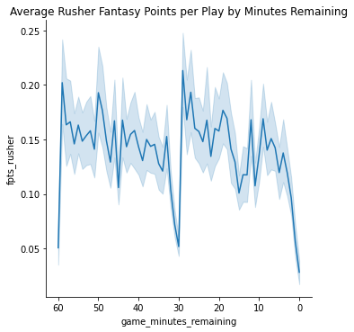

```python
rel = sns.relplot(data=pbp, x='game_minutes_remaining', y='fpts_rusher',
                  kind='line').set(title='Average Rusher Fantasy Points per Play by Minutes Remaining')
rel.axes[0][0].invert_xaxis()
```

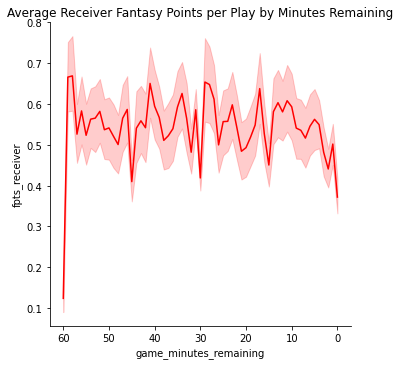

```python
rel = sns.relplot(data=pbp, x='game_minutes_remaining', y='fpts_receiver',
                  kind='line', color='Red').set(title='Average Receiver Fantasy Points per Play by Minutes Remaining')
rel.axes[0][0].invert_xaxis()
```

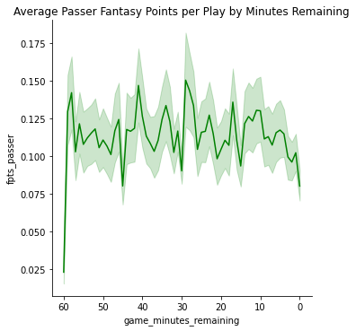

```python
rel = sns.relplot(data=pbp, x='game_minutes_remaining', y='fpts_passer',
                  kind='line', color='Green').set(title='Average Passer Fantasy Points per Play by Minutes Remaining')
rel.axes[0][0].invert_xaxis()
```

[output not shown]

[output not shown]

[output not shown]